# Analiza materiałów do baterii - Materials Project

Dawid Stasiak

2024-11-19

## Wstęp

Niniejszy raport przedstawia analizę bazy danych materiałów wykorzystywanych w tworzeniu baterii, pochodzących z projektu Materials Project. Materials Project to inicjatywa naukowa Departamentu Energii USA, której celem jest dostarczanie otwartych danych i narzędzi do analizy materiałów.

## Wczytanie i przygotowanie danych

Wczytanie surowych danych z pliku CSV i wstępna analiza ich struktury.

```r
# Wczytanie danych z pliku CSV
batteries_raw_data <- read.csv("mp_batteries.csv")
batteries_raw_tbl <- as_tibble(batteries_raw_data)
```

### Struktura danych

```r
str(batteries_raw_tbl)
```

```
## tibble [4,351 × 17] (S3: tbl_df/tbl/data.frame)
##  $ Battery.ID               : chr [1:4351] "mp-30_Al" "mp-1022721_Al" "mp-8637_Al" "mp-129_Al" ...
##  $ Battery.Formula          : chr [1:4351] "Al0-2Cu" "Al1-3Cu" "Al0-5Mo" "Al0-12Mo" ...
##  $ Working.Ion              : chr [1:4351] "Al" "Al" "Al" "Al" ...
##  $ Formula.Charge           : chr [1:4351] "Cu" "AlCu" "Mo" "Mo" ...
##  $ Formula.Discharge        : chr [1:4351] "Al2Cu" "Al3Cu" "Al5Mo" "Al12Mo" ...
##  $ Max.Delta.Volume         : num [1:4351] 3.04 1.24 4.76 12.72 12.49 ...
##  $ Average.Voltage          : num [1:4351] 0.089 -0.0216 0.1228 0.0431 0.0292 ...
##  $ Gravimetric.Capacity     : num [1:4351] 1368 1113 1742 2299 1901 ...
##  $ Volumetric.Capacity      : num [1:4351] 5563 4419 7176 7346 7333 ...
##  $ Gravimetric.Energy       : num [1:4351] 121.8 -24 213.8 99.1 55.6 ...
##  $ Volumetric.Energy        : num [1:4351] 495.3 -95.4 880.9 316.8 214.4 ...
##  $ Atomic.Fraction.Charge   : num [1:4351] 0 0.5 0 0 0 ...
##  $ Atomic.Fraction.Discharge: num [1:4351] 0.667 0.75 0.833 0.923 0.923 ...
##  $ Stability.Charge         : num [1:4351] 0 0.0741 0.4115 0 0 ...
##  $ Stability.Discharge      : num [1:4351] 0 0.0962 0.0452 0.0114 0 ...
##  $ Steps                    : int [1:4351] 1 1 1 1 1 1 1 1 1 1 ...
##  $ Max.Voltage.Step         : num [1:4351] 0 0 0 0 0 0 0 0 0 0 ...
```

### Pierwsze wiersze zbioru danych

```r
head(batteries_raw_tbl)
```

```
## # A tibble: 6 × 17
##   Battery.ID    Battery.Formula Working.Ion Formula.Charge Formula.Discharge
##   <chr>         <chr>           <chr>       <chr>          <chr>
## 1 mp-30_Al      Al0-2Cu         Al          Cu             Al2Cu
## 2 mp-1022721_Al Al1-3Cu         Al          AlCu           Al3Cu
## 3 mp-8637_Al    Al0-5Mo         Al          Mo             Al5Mo
## 4 mp-129_Al     Al0-12Mo        Al          Mo             Al12Mo
## 5 mp-91_Al      Al0-12W         Al          W              Al12W
## 6 mp-1055908_Al Al0-12Mn        Al          Mn             MnAl12
## # ℹ 12 more variables: Max.Delta.Volume <dbl>, Average.Voltage <dbl>,
## #   Gravimetric.Capacity <dbl>, Volumetric.Capacity <dbl>,
## #   Gravimetric.Energy <dbl>, Volumetric.Energy <dbl>,
## #   Atomic.Fraction.Charge <dbl>, Atomic.Fraction.Discharge <dbl>,
## #   Stability.Charge <dbl>, Stability.Discharge <dbl>, Steps <int>,
## #   Max.Voltage.Step <dbl>
```

### Analiza jakości danych

Sprawdzenie jakości danych pod kątem brakujących wartości, duplikatów oraz potencjalnych nieprawidłowości w danych.

```r
# Sprawdzenie brakujących wartości w każdej kolumnie
missing_values <- colSums(is.na(batteries_raw_tbl))
missing_values_tbl <- tibble(
  column = names(missing_values),
  missing_count = missing_values
) %>%
  filter(missing_count > 0)

if (nrow(missing_values_tbl) > 0) {
  print("Kolumny z brakującymi wartościami:")
  print(missing_values_tbl)
} else {
  print("Brak brakujących wartości w zbiorze danych")
}
```

```
## [1] "Brak brakujących wartości w zbiorze danych"
```

```r
# Sprawdzenie duplikatów
duplicates_count <- sum(duplicated(batteries_raw_tbl))
print(paste("Liczba zduplikowanych wierszy:", duplicates_count))
```

```
## [1] "Liczba zduplikowanych wierszy: 0"
```

```r
if (duplicates_count > 0) {
  # Pokazanie przykładowych duplikatów
  print("Przykładowe zduplikowane wiersze:")
  batteries_raw_tbl[duplicated(batteries_raw_tbl) | duplicated(batteries_raw_tbl, fromLast = TRUE), ]
}
```

### Proces czyszczenia danych

```r
# Tworzenie czystego zbioru danych
batteries_data_tbl <- batteries_raw_tbl %>%
  rename_all(tolower) %>%
  rename_all(~ gsub("\\.", "_", .)) %>%
  # Konwersja zmiennych numerycznych do odpowiednich typów
  mutate(
    max_delta_volume = as.numeric(max_delta_volume),
    average_voltage = as.numeric(average_voltage),
    gravimetric_capacity = as.numeric(gravimetric_capacity),
    volumetric_capacity = as.numeric(volumetric_capacity),
    gravimetric_energy = as.numeric(gravimetric_energy),
    volumetric_energy = as.numeric(volumetric_energy),
    atomic_fraction_charge = as.numeric(atomic_fraction_charge),
    atomic_fraction_discharge = as.numeric(atomic_fraction_discharge),
    stability_charge = as.numeric(stability_charge),
    stability_discharge = as.numeric(stability_discharge),
    steps = as.integer(steps),
    max_voltage_step = as.numeric(max_voltage_step)
  )

# Sprawdzenie struktury wyczyszczonych danych
str(batteries_data_tbl)
```

```
## tibble [4,351 × 17] (S3: tbl_df/tbl/data.frame)
##  $ battery_id               : chr [1:4351] "mp-30_Al" "mp-1022721_Al" "mp-8637_Al" "mp-129_Al" ...
##  $ battery_formula          : chr [1:4351] "Al0-2Cu" "Al1-3Cu" "Al0-5Mo" "Al0-12Mo" ...
##  $ working_ion              : chr [1:4351] "Al" "Al" "Al" "Al" ...
##  $ formula_charge           : chr [1:4351] "Cu" "AlCu" "Mo" "Mo" ...
##  $ formula_discharge        : chr [1:4351] "Al2Cu" "Al3Cu" "Al5Mo" "Al12Mo" ...
##  $ max_delta_volume         : num [1:4351] 3.04 1.24 4.76 12.72 12.49 ...
##  $ average_voltage          : num [1:4351] 0.089 -0.0216 0.1228 0.0431 0.0292 ...
##  $ gravimetric_capacity     : num [1:4351] 1368 1113 1742 2299 1901 ...
##  $ volumetric_capacity      : num [1:4351] 5563 4419 7176 7346 7333 ...
##  $ gravimetric_energy       : num [1:4351] 121.8 -24 213.8 99.1 55.6 ...
##  $ volumetric_energy        : num [1:4351] 495.3 -95.4 880.9 316.8 214.4 ...
##  $ atomic_fraction_charge   : num [1:4351] 0 0.5 0 0 0 ...
##  $ atomic_fraction_discharge: num [1:4351] 0.667 0.75 0.833 0.923 0.923 ...
##  $ stability_charge         : num [1:4351] 0 0.0741 0.4115 0 0 ...
##  $ stability_discharge      : num [1:4351] 0 0.0962 0.0452 0.0114 0 ...
##  $ steps                    : int [1:4351] 1 1 1 1 1 1 1 1 1 1 ...
##  $ max_voltage_step         : num [1:4351] 0 0 0 0 0 0 0 0 0 0 ...
```

```r
# Zapisanie wyczyszczonych danych
write.csv(batteries_data_tbl, "mp_batteries_clean.csv", row.names = FALSE)
```

### Dokumentacja zbioru danych

Poniżej przedstawiono opis wszystkich zmiennych w wyczyszczonym zbiorze danych:

- **battery_id** - Identyfikator baterii
- **battery_formula** - Wzór chemiczny materiału baterii
- **working_ion** - Główny jon, który odpowiada za transport ładunku w baterii
- **formula_charge** - Wzór chemiczny materiału baterii w stanie naładowanym
- **formula_discharge** - Wzór chemiczny materiału baterii w stanie rozładowanym
- **max_delta_volume** [%] - Zmiana objętości w % dla danego kroku napięcia za pomocą wzoru: max(charge, discharge)/min(charge, discharge) -1
- **average_voltage** [V] - Średnie napięcie dla poszczególnego kroku napięcia
- **gravimetric_capacity** [mAh/g] - Pojemność grawimetryczna, czyli ilość energii na jednostkę masy
- **volumetric_capacity** [mAh/cm³] - Pojemność wolumetryczna, czyli ilość energii na jednostkę objętości
- **gravimetric_energy** [Wh/kg] - Gęstość energii w odniesieniu do masy baterii
- **volumetric_energy** [Wh/L] - Gęstość energii w odniesieniu do objętości baterii
- **atomic_fraction_charge** - Udział atomowy składników w stanie naładowanym
- **atomic_fraction_discharge** - Udział atomowy składników w stanie rozładowanym
- **stability_charge** - Wskaźnik stabilności materiału w stanie naładowanym
- **stability_discharge** - Wskaźnik stabilności materiału w stanie rozładowanym
- **steps** - Liczba odrębnych kroków napięcia od pełnego naładowania do rozładowania, oparta na stabilnych stanach pośrednich
- **max_voltage_step** [V] - Maksymalna bezwzględna różnica między sąsiednimi krokami napięcia

## Analiza rozkładów zmiennych

### Rozkłady zmiennych numerycznych

W tej sekcji przedstawiono rozkłady wszystkich zmiennych numerycznych w naszym zbiorze danych. Dla każdej zmiennej wygenerowano histogram, co pozwala na wizualną ocenę charakteru rozkładu. Wykresy zostały ułożone w siatce po dwa w rzędzie dla lepszej czytelności. Zastosowano spójną stylistykę z jasnoniebieskimi histogramami.

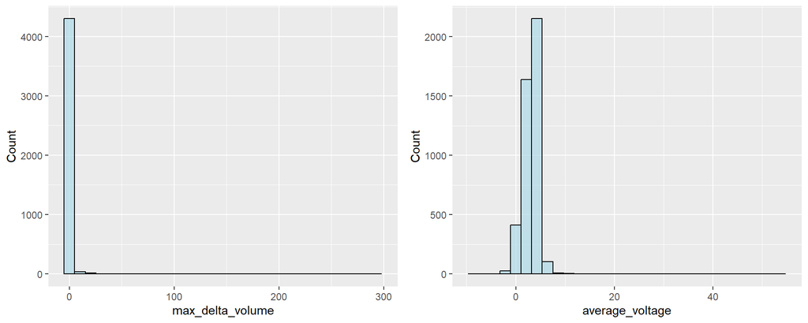

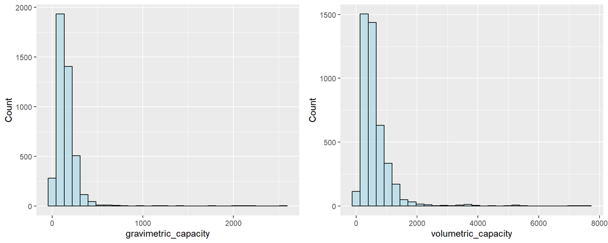

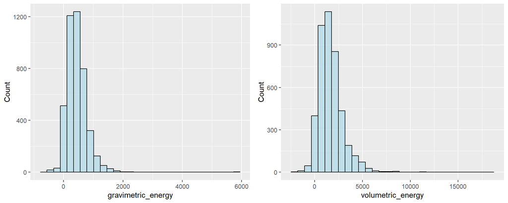

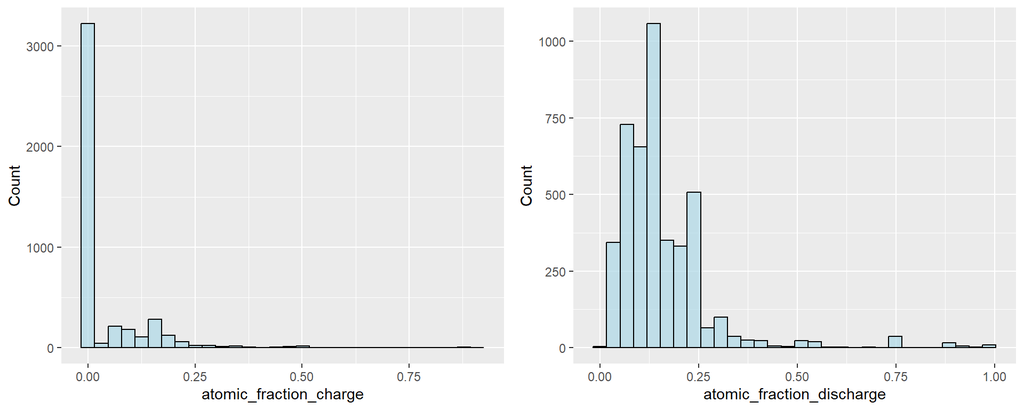

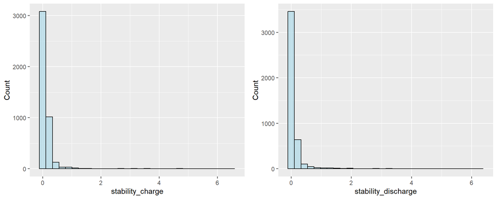

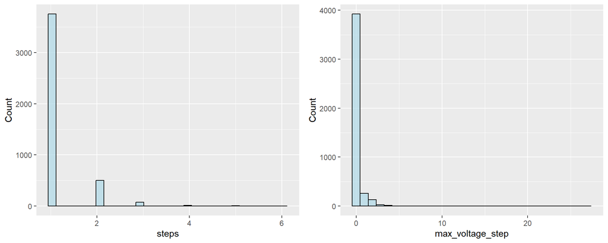

```r
numeric_vars <- c(
  "max_delta_volume", "average_voltage", "gravimetric_capacity",
  "volumetric_capacity", "gravimetric_energy", "volumetric_energy",
  "atomic_fraction_charge", "atomic_fraction_discharge",
  "stability_charge", "stability_discharge",
  "steps", "max_voltage_step"
)

create_distribution_plot <- function(data, var_name) {
  ggplot(data, aes(x = .data[[var_name]])) +
    geom_histogram(
      fill = "lightblue",
      color = "black",
      alpha = 0.7
    ) +
    labs(x = var_name, y = "Count")
}

plots_list <- lapply(numeric_vars, function(var) {
  create_distribution_plot(batteries_data_tbl, var)
})

for (i in seq(1, length(plots_list), by = 2)) {
  if (i == length(plots_list)) {
    print(plots_list[[i]])
  } else {
    grid.arrange(plots_list[[i]], plots_list[[i + 1]], ncol = 2)
  }
}
```

### Analiza zmiennych kategorycznych

#### Rozkład jonów roboczych (working ion)

W tej części analizujemy częstość występowania poszczególnych jonów roboczych w badanych materiałach bateryjnych. Wykres słupkowy przedstawia liczbę materiałów wykorzystujących poszczególne jony jako nośniki ładunku.

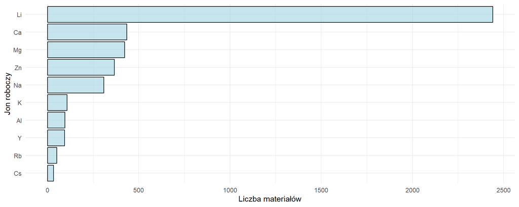

```r
working_ion_plot <- batteries_data_tbl %>%
  count(working_ion, sort = TRUE) %>%
  ggplot(aes(x = reorder(working_ion, n), y = n)) +
  geom_bar(stat = "identity", fill = "lightblue", color = "black", alpha = 0.7) +
  coord_flip() +
  labs(x = "Jon roboczy", y = "Liczba materiałów") +
  theme_minimal()

print(working_ion_plot)
```

#### Porównanie wzorów chemicznych w stanie naładowanym i rozładowanym

Poniższa analiza przedstawia, jak często występują różne kombinacje wzorów chemicznych w stanie naładowanym i rozładowanym. Ze względu na dużą liczbę unikalnych kombinacji, przedstawiono tylko najczęściej występujące przypadki.

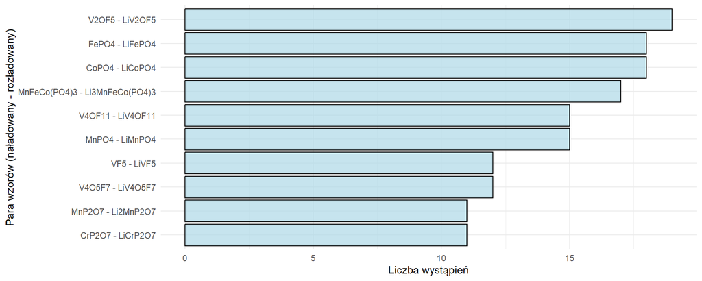

```r
formula_comparison_plot <- batteries_data_tbl %>%
  count(formula_charge, formula_discharge, sort = TRUE) %>%
  head(10) %>%
  mutate(
    pair_label = paste(formula_charge, "-", formula_discharge),
  ) %>%
  ggplot(aes(x = reorder(pair_label, n), y = n)) +
  geom_bar(stat = "identity", fill = "lightblue", color = "black", alpha = 0.7) +
  coord_flip() +
  labs(
    x = "Para wzorów (naładowany - rozładowany)",
    y = "Liczba wystąpień"
  ) +
  theme_minimal()

print(formula_comparison_plot)
```

### Podsumowanie statystyczne

W tej części przedstawiono podstawowe statystyki opisowe dla wszystkich zmiennych numerycznych w zbiorze danych. Dla każdej zmiennej obliczono wartości centralne (średnia, mediana), miary rozproszenia (odchylenie standardowe, rozstęp) oraz kwartyle.

```r
batteries_data_tbl %>%
  select(numeric_vars) %>%
  summarise(across(everything(), list(
    min = ~ min(.),
    max = ~ max(.),
    q1 = ~ quantile(., 0.25),
    median = ~ median(.),
    mean = ~ mean(.),
    q3 = ~ quantile(., 0.75),
    sd = ~ sd(.)
  ))) %>%
  pivot_longer(everything(),
    names_to = c("variable", "statistic"),
    names_sep = "_(?=[^_]+$)"
  ) %>%
  pivot_wider(names_from = statistic, values_from = value) %>%
  knitr::kable(
    caption = "Statystyki opisowe dla zmiennych numerycznych",
    digits = 3
  )
```

Statystyki opisowe dla zmiennych numerycznych

| variable | min | max | q1 | median | mean | q3 | sd |
| --- | --- | --- | --- | --- | --- | --- | --- |
| max_delta_volume | 0.000 | 293.193 | 0.017 | 0.042 | 0.375 | 0.086 | 6.852 |
| average_voltage | -7.755 | 54.569 | 2.226 | 3.301 | 3.083 | 4.019 | 1.822 |
| gravimetric_capacity | 5.177 | 2557.627 | 88.108 | 130.691 | 158.291 | 187.600 | 164.914 |
| volumetric_capacity | 24.079 | 7619.191 | 311.615 | 507.031 | 610.624 | 722.755 | 563.853 |
| gravimetric_energy | -583.546 | 5926.950 | 211.692 | 401.788 | 444.106 | 614.416 | 351.048 |
| volumetric_energy | -2208.075 | 18305.898 | 821.625 | 1463.788 | 1664.048 | 2252.257 | 1297.799 |
| atomic_fraction_charge | 0.000 | 0.909 | 0.000 | 0.000 | 0.040 | 0.048 | 0.089 |
| atomic_fraction_discharge | 0.007 | 0.993 | 0.087 | 0.143 | 0.159 | 0.200 | 0.120 |
| stability_charge | 0.000 | 6.487 | 0.033 | 0.073 | 0.143 | 0.132 | 0.378 |
| stability_discharge | 0.000 | 6.278 | 0.020 | 0.049 | 0.122 | 0.093 | 0.352 |
| steps | 1.000 | 6.000 | 1.000 | 1.000 | 1.167 | 1.000 | 0.464 |
| max_voltage_step | 0.000 | 26.961 | 0.000 | 0.000 | 0.150 | 0.000 | 0.630 |

### Kluczowe wnioski

Na podstawie przeprowadzonej analizy rozkładów zmiennych można wyciągnąć następujące wnioski:

1. **Rozkłady zmiennych numerycznych**
   - Większość zmiennych energetycznych (gravimetric_energy, volumetric_energy, gravimetric_capacity) wykazuje rozkład prawoskośny, co sugeruje występowanie materiałów o nietypowo wysokich wartościach energetycznych.
   - Zmienna max_delta_volume charakteryzuje się dużą koncentracją wartości w dolnym zakresie, co wskazuje, że większość badanych materiałów cechuje się relatywnie małymi zmianami objętości podczas cyklu ładowania/rozładowania.
2. **Analiza zmiennych kategorycznych**
   - Dominującym jonem roboczym w badanych materiałach jest Li (lit), co potwierdza jego kluczową rolę w technologii baterii.
   - Analiza par wzorów chemicznych wskazuje na występowanie charakterystycznych wzorców transformacji podczas procesów ładowania i rozładowania.
3. **Charakterystyka statystyczna**
   - Obserwujemy znaczące różnice między średnią a medianą dla zmiennych energetycznych, co potwierdza asymetrię ich rozkładów.
   - Duże wartości odchylenia standardowego dla zmiennych energetycznych sugerują znaczące zróżnicowanie właściwości badanych materiałów.

## Analiza korelacji

### Macierz korelacji

W tej części przeprowadzimy analizę korelacji między zmiennymi numerycznymi w naszym zbiorze danych. Pozwoli to na identyfikację istotnych zależności między różnymi właściwościami materiałów bateryjnych.

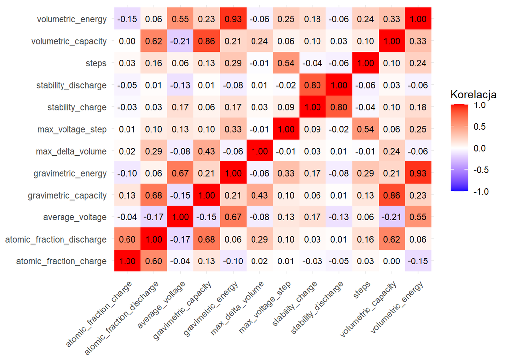

```r
correlation_matrix <- batteries_data_tbl %>%
  select(numeric_vars) %>%
  cor()

correlation_long <- correlation_matrix %>%
  as.data.frame() %>%
  mutate(variable1 = colnames(correlation_matrix)) %>%
  pivot_longer(-variable1,
    names_to = "variable2",
    values_to = "correlation"
  )

ggplot(
  correlation_long,
  aes(x = variable1, y = variable2, fill = correlation)
) +
  geom_tile() +
  scale_fill_gradient2(
    low = "blue", mid = "white", high = "red",
    midpoint = 0, limits = c(-1, 1)
  ) +
  geom_text(aes(label = sprintf("%.2f", correlation)), size = 3) +
  theme_minimal() +
  theme(
    axis.text.x = element_text(angle = 45, hjust = 1),
    axis.title = element_blank()
  ) +
  labs(fill = "Korelacja")
```

### Najsilniejsze korelacje

W poniższej tabeli przedstawiono 10 najsilniejszych korelacji między zmiennymi w zbiorze danych, uporządkowanych według wartości bezwzględnej współczynnika korelacji. Pozwala to na szybką identyfikację najistotniejszych zależności między właściwościami materiałów bateryjnych.

```r
top_correlations <- correlation_long %>%
  filter(variable1 < variable2) %>% # Only keep one combination of each pair
  arrange(desc(abs(correlation))) %>%
  head(10)

knitr::kable(
  top_correlations %>%
    mutate(correlation = round(correlation, 3)) %>%
    rename(
      "Zmienna 1" = variable1,
      "Zmienna 2" = variable2,
      "Współczynnik korelacji" = correlation
    ),
  caption = "10 najsilniejszych korelacji między zmiennymi"
)
```

10 najsilniejszych korelacji między zmiennymi

| Zmienna 1 | Zmienna 2 | Współczynnik korelacji |
| --- | --- | --- |
| gravimetric_energy | volumetric_energy | 0.928 |
| gravimetric_capacity | volumetric_capacity | 0.858 |
| stability_charge | stability_discharge | 0.803 |
| atomic_fraction_discharge | gravimetric_capacity | 0.681 |
| average_voltage | gravimetric_energy | 0.666 |
| atomic_fraction_discharge | volumetric_capacity | 0.618 |
| atomic_fraction_charge | atomic_fraction_discharge | 0.597 |
| average_voltage | volumetric_energy | 0.555 |
| max_voltage_step | steps | 0.535 |
| gravimetric_capacity | max_delta_volume | 0.434 |

### Szczegółowa analiza najsilniejszych korelacji

Poniżej przedstawiono wykresy rozrzutu dla trzech najsilniejszych korelacji między zmiennymi. Wykresy te pozwalają na dokładniejszą analizę charakteru zależności między wybranymi parami zmiennych.

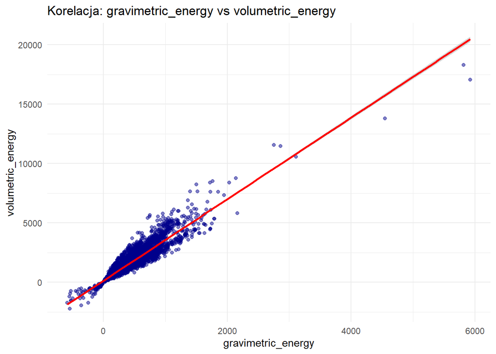

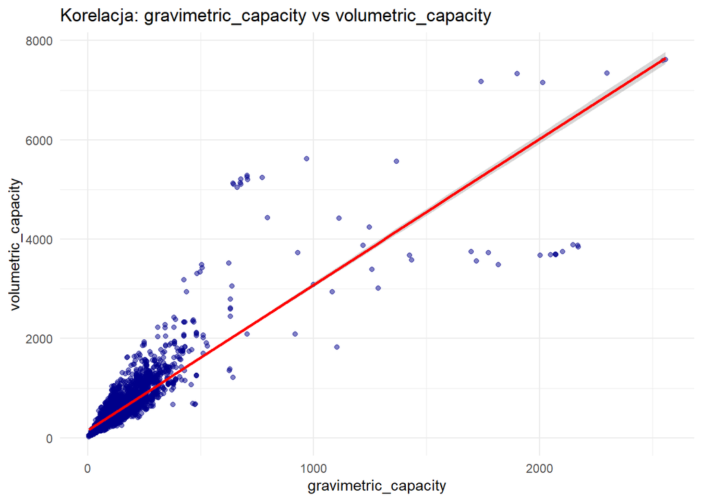

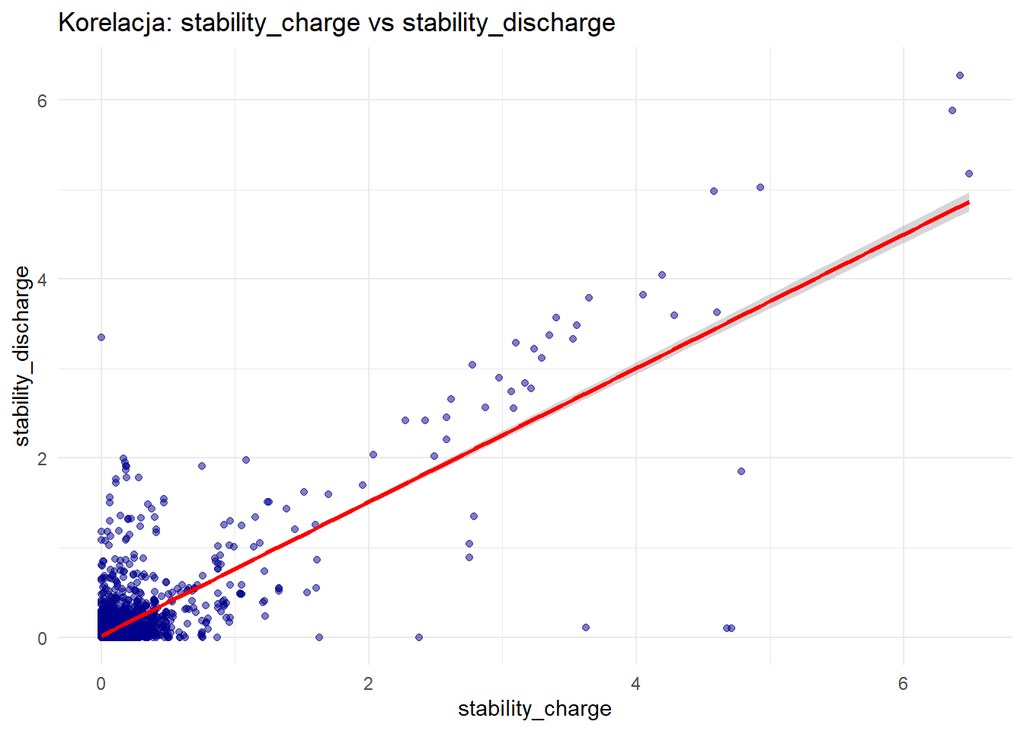

```r
top_3_correlations <- top_correlations %>%
  head(3)

create_scatter_plot <- function(data, var1, var2) {
  ggplot(data, aes(x = .data[[var1]], y = .data[[var2]])) +
    geom_point(alpha = 0.5, color = "darkblue") +
    geom_smooth(method = "lm", color = "red") +
    theme_minimal() +
    labs(
      title = paste("Korelacja:", var1, "vs", var2),
      x = var1,
      y = var2
    )
}

for (i in 1:3) {
  print(create_scatter_plot(
    batteries_data_tbl,
    top_3_correlations$variable1[i],
    top_3_correlations$variable2[i]
  ))
}
```